# Obesity Levels Based on Eating Habits, Physical Condition, and Other Factors

> Obesity Levels Based on Eating Habits, Physical Condition, and Other Factors

> > Table of Contents

> > Project Topic and Overview

> > > Overview of Project Models

> > > Goals

> > Data Source

> > > APA Format for Data Source

> > Libraries and Data Read In

> > > Original Data Size and Information

> > Data Cleaning

> > > Column Name Changes

> > > Adding Body Mass Index (BMI)

> > > Range of BMI Values by Weight Category

> > > Revising the Weight/Obesity Categories

> > > Deleting Columns

> > > Adjusting Cell Values

> > > One Hot Encoding

> > > Finalizing Dataset

> > Exploratory Data Analysis (EDA)

> > > Correlation Matrix

> > > Pair plot of BMI vs. Age

> > > Variance Inflation Factor (VIF)

> > OLS Regression

> > > Training and Testing Split

> > > Ranking Linear Models by Mean Squared Error (MSE)

> > > > Backward Elimation by P-Value on Lowest MSE Model

> > > Forward Selection by P-Value

> > > Diagnostic Plots

> > > OLS Regression Conclusion

> > Ensemble Methods

> > > Bagging with Random Forests and Boosting with XGBoost

> > > Random Forest Classification

> > > > New $X$ and $y$ with Training and Testing Split

> > > > Hyperparameter Tuning

> > > > Plots and Results

> > > > > Accuracy Plot

> > > > > Confusion Matrix

> > > > > Classification Report

> > > XGBoost Classification

> > > > New $y$ with Training and Testing Split

> > > > Hyperparameter Tuning

> > > > Plots and Results

> > > > > Accuracy Plot

> > > > > Confusion Matrix

> > > > > Classification Report

> > > Random Forest vs. XGBoost

> > > > Accuracy Comparison

> > > > Report Comparison

> > Conclusion

> > > Best Model

> > > Difficulties and Takeaways

## Project Topic and Overview

This project will look at prediction and classification of obesity levels based off of eating habits, physical condition, lifestyle, and other factors.

### Overview of Project Models

This project will look at three different models.

1. The first model will use OLS Regression. This method is one of the simpler approaches and we will show that it does not perform very well. This model will be used in contrast to more sophisticated supervised machine learning methods. While this method fails in doing an adequate job at predicting, we will show that other models are more succesful.
2. The next model will use the ensemble method of Random Forests that was covered in lecture.
3. Lastly, we will look at gradient boosting with XGBoost. The method was mentioned in lecture, but not covered in detail.

### Goals

The main goal of this project is to be able to predict or classify accurately based on the features provided. The orginal dataset has 16 features and was obtained by survey. Nearly all features were binary or ordinal values. These categorical values along with response bias pose a challenge in ensuring that the model(s) are accurate.

A secondary goal is to show a comparison of a simple model vs. more advanced models. We will show where the simple model fails and discuss alternative options.

## Data Source

The dataset is called **Estimation of Obesity Levels Based On Eating Habits and Physical Condition** and is from the **UC Irvine Machine Learning Repository**. The dataset and more information about it can be found at the following link:

https://archive.ics.uci.edu/dataset/544/estimation+of+obesity+levels+based+on+eating+habits+and+physical+condition

According to the description, the dataset includes "data for the estimation of obesity levels in individuals from the countries of Mexico, Peru and Colombia, based on their eating habits and physical condition. The data contains 17 attributes and 2111 records, the records are labeled with the class variable NObesity (Obesity Level), that allows classification of the data using the values of Insufficient Weight, Normal Weight, Overweight Level I, Overweight Level II, Obesity Type I, Obesity Type II and Obesity Type III. 77% of the data was generated synthetically using the Weka tool and the SMOTE filter, 23% of the data was collected directly from users through a web platform."

There is also an introductory paper that accompanies the dataset that can be found at the following link:

https://www.semanticscholar.org/paper/Dataset-for-estimation-of-obesity-levels-based-on-Palechor-Manotas/35b40bacd2ffa9370885b7a3004d88995fd1d011

### APA Format for Data Source

Mendoza Palechor, F., & De la Hoz Manotas, A. (2019, August 1). "*Estimation of Obesity Levels Based On Eating Habits and Physical Condition*":

> > UC Irvine Machine Learning Repository.  
> > https://archive.ics.uci.edu/dataset/544/estimation+of+obesity+levels+based+on+eating+habits+and+physical+condition

## Libraries and Data Read In

```python
import matplotlib.pyplot as plt
import numpy as np
import pandas as pd
import seaborn as sns
import statsmodels.api as sm
import statsmodels.formula.api as smf
import xgboost as xgb

from itertools import combinations

from sklearn.ensemble import RandomForestClassifier
from sklearn.linear_model import LinearRegression
from sklearn.metrics import mean_squared_error, accuracy_score, confusion_matrix, classification_report
from sklearn.model_selection import train_test_split
from sklearn.preprocessing import OneHotEncoder

from statsmodels.graphics.gofplots import qqplot
from statsmodels.stats.outliers_influence import variance_inflation_factor
```

```python
data = pd.read_csv('ObesityDataSet_raw_and_data_sinthetic.csv')
```

### Original Data Size and Information

The data that we read in is **tabulated data**. The sample size is 2,111 with 16 features and 1 target variable. Information on the variables can be found in the table below. The table also includes context for each column. We will be making changes in the Data Cleaning section, so the variables will change a bit.

| Variable Name | Role | Type | Demographic | Description | Units | Missing Values |
| --- | --- | --- | --- | --- | --- | --- |
| Gender | Feature | Categorical | Gender |  |  | no |
| Age | Feature | Continuous | Age |  |  | no |
| Height | Feature | Continuous |  |  |  | no |
| Weight | Feature | Continuous |  |  |  | no |
| family_history_with_overweight | Feature | Binary |  | Has a family member suffered or suffers from overweight? |  | no |
| FAVC | Feature | Binary |  | Do you eat high caloric food frequently? |  | no |
| FCVC | Feature | Integer |  | Do you usually eat vegetables in your meals? |  | no |
| NCP | Feature | Continuous |  | How many main meals do you have daily? |  | no |
| CAEC | Feature | Categorical |  | Do you eat any food between meals? |  | no |
| SMOKE | Feature | Binary |  | Do you smoke? |  | no |
| CH2O | Feature | Continuous |  | How much water do you drink daily? |  | no |
| SCC | Feature | Binary |  | Do you monitor the calories you eat daily? |  | no |
| FAF | Feature | Continuous |  | How often do you have physical activity? |  | no |
| TUE | Feature | Integer |  | How much time do you use technological devices such as cell phone, videogames, television, computer and others? |  | no |
| CALC | Feature | Categorical |  | How often do you drink alcohol? |  | no |
| MTRANS | Feature | Categorical |  | Which transportation do you usually use? |  | no |
| NObeyesdad | Target | Categorical |  | Obesity level |  | no |

In the following cells we can see the data size once more, the data types of the columns, the first few rows of the data, and a quick statistical summary of the dataset.

```python
data.info()
data.head()
```

```
<class 'pandas.core.frame.DataFrame'>
RangeIndex: 2111 entries, 0 to 2110
Data columns (total 17 columns):
 #   Column                          Non-Null Count  Dtype
---  ------                          --------------  -----
 0   Gender                          2111 non-null   object
 1   Age                             2111 non-null   float64
 2   Height                          2111 non-null   float64
 3   Weight                          2111 non-null   float64
 4   family_history_with_overweight  2111 non-null   object
 5   FAVC                            2111 non-null   object
 6   FCVC                            2111 non-null   float64
 7   NCP                             2111 non-null   float64
 8   CAEC                            2111 non-null   object
 9   SMOKE                           2111 non-null   object
 10  CH2O                            2111 non-null   float64
 11  SCC                             2111 non-null   object
 12  FAF                             2111 non-null   float64
 13  TUE                             2111 non-null   float64
 14  CALC                            2111 non-null   object
 15  MTRANS                          2111 non-null   object
 16  NObeyesdad                      2111 non-null   object
dtypes: float64(8), object(9)
memory usage: 280.5+ KB
```

|  | Gender | Age | Height | Weight | family_history_with_overweight | FAVC | FCVC | NCP | CAEC | SMOKE | CH2O | SCC | FAF | TUE | CALC | MTRANS | NObeyesdad |
| --- | --- | --- | --- | --- | --- | --- | --- | --- | --- | --- | --- | --- | --- | --- | --- | --- | --- |
| 0 | Female | 21.0 | 1.62 | 64.0 | yes | no | 2.0 | 3.0 | Sometimes | no | 2.0 | no | 0.0 | 1.0 | no | Public_Transportation | Normal_Weight |
| 1 | Female | 21.0 | 1.52 | 56.0 | yes | no | 3.0 | 3.0 | Sometimes | yes | 3.0 | yes | 3.0 | 0.0 | Sometimes | Public_Transportation | Normal_Weight |
| 2 | Male | 23.0 | 1.80 | 77.0 | yes | no | 2.0 | 3.0 | Sometimes | no | 2.0 | no | 2.0 | 1.0 | Frequently | Public_Transportation | Normal_Weight |
| 3 | Male | 27.0 | 1.80 | 87.0 | no | no | 3.0 | 3.0 | Sometimes | no | 2.0 | no | 2.0 | 0.0 | Frequently | Walking | Overweight_Level_I |
| 4 | Male | 22.0 | 1.78 | 89.8 | no | no | 2.0 | 1.0 | Sometimes | no | 2.0 | no | 0.0 | 0.0 | Sometimes | Public_Transportation | Overweight_Level_II |

```python
data.describe()
```

|  | Age | Height | Weight | FCVC | NCP | CH2O | FAF | TUE |
| --- | --- | --- | --- | --- | --- | --- | --- | --- |
| count | 2111.000000 | 2111.000000 | 2111.000000 | 2111.000000 | 2111.000000 | 2111.000000 | 2111.000000 | 2111.000000 |
| mean | 24.312600 | 1.701677 | 86.586058 | 2.419043 | 2.685628 | 2.008011 | 1.010298 | 0.657866 |
| std | 6.345968 | 0.093305 | 26.191172 | 0.533927 | 0.778039 | 0.612953 | 0.850592 | 0.608927 |
| min | 14.000000 | 1.450000 | 39.000000 | 1.000000 | 1.000000 | 1.000000 | 0.000000 | 0.000000 |
| 25% | 19.947192 | 1.630000 | 65.473343 | 2.000000 | 2.658738 | 1.584812 | 0.124505 | 0.000000 |
| 50% | 22.777890 | 1.700499 | 83.000000 | 2.385502 | 3.000000 | 2.000000 | 1.000000 | 0.625350 |
| 75% | 26.000000 | 1.768464 | 107.430682 | 3.000000 | 3.000000 | 2.477420 | 1.666678 | 1.000000 |
| max | 61.000000 | 1.980000 | 173.000000 | 3.000000 | 4.000000 | 3.000000 | 3.000000 | 2.000000 |

## Data Cleaning

### Column Name Changes

The column names are a bit confusing. We'll update the column names so they're easier to understand without having to look up the variable information from the source. We'll use the table from the Libraries and Data Read In section to to make the contextual changes.

```python
#renames the columns of the data
renameCol = ['gender', 'age', 'height', 'weight', 'family_hist', 'high_cal', 'vegetable_cons', 'meal_num', 'between_meals', 'smoke', 'water_cons', 'monitor_cal', 'physical_act', 'tech_time', 'alcohol_cons', 'transport_type', 'weight_category']

data.columns = renameCol
data.head()
```

|  | gender | age | height | weight | family_hist | high_cal | vegetable_cons | meal_num | between_meals | smoke | water_cons | monitor_cal | physical_act | tech_time | alcohol_cons | transport_type | weight_category |
| --- | --- | --- | --- | --- | --- | --- | --- | --- | --- | --- | --- | --- | --- | --- | --- | --- | --- |
| 0 | Female | 21.0 | 1.62 | 64.0 | yes | no | 2.0 | 3.0 | Sometimes | no | 2.0 | no | 0.0 | 1.0 | no | Public_Transportation | Normal_Weight |
| 1 | Female | 21.0 | 1.52 | 56.0 | yes | no | 3.0 | 3.0 | Sometimes | yes | 3.0 | yes | 3.0 | 0.0 | Sometimes | Public_Transportation | Normal_Weight |
| 2 | Male | 23.0 | 1.80 | 77.0 | yes | no | 2.0 | 3.0 | Sometimes | no | 2.0 | no | 2.0 | 1.0 | Frequently | Public_Transportation | Normal_Weight |
| 3 | Male | 27.0 | 1.80 | 87.0 | no | no | 3.0 | 3.0 | Sometimes | no | 2.0 | no | 2.0 | 0.0 | Frequently | Walking | Overweight_Level_I |
| 4 | Male | 22.0 | 1.78 | 89.8 | no | no | 2.0 | 1.0 | Sometimes | no | 2.0 | no | 0.0 | 0.0 | Sometimes | Public_Transportation | Overweight_Level_II |

### Adding Body Mass Index (BMI)

According to the paper that accompanies the data, the obesity categories are based off of BMI. We'll add a BMI column in so that we can see it for each person. Note that height is already in $m$ and weight is already in $kg$.

```python
#calculates bmi and adds a bmi column
data['bmi'] = data['weight']/(data['height'] ** 2)
data.head()
```

|  | gender | age | height | weight | family_hist | high_cal | vegetable_cons | meal_num | between_meals | smoke | water_cons | monitor_cal | physical_act | tech_time | alcohol_cons | transport_type | weight_category | bmi |
| --- | --- | --- | --- | --- | --- | --- | --- | --- | --- | --- | --- | --- | --- | --- | --- | --- | --- | --- |
| 0 | Female | 21.0 | 1.62 | 64.0 | yes | no | 2.0 | 3.0 | Sometimes | no | 2.0 | no | 0.0 | 1.0 | no | Public_Transportation | Normal_Weight | 24.386526 |
| 1 | Female | 21.0 | 1.52 | 56.0 | yes | no | 3.0 | 3.0 | Sometimes | yes | 3.0 | yes | 3.0 | 0.0 | Sometimes | Public_Transportation | Normal_Weight | 24.238227 |
| 2 | Male | 23.0 | 1.80 | 77.0 | yes | no | 2.0 | 3.0 | Sometimes | no | 2.0 | no | 2.0 | 1.0 | Frequently | Public_Transportation | Normal_Weight | 23.765432 |
| 3 | Male | 27.0 | 1.80 | 87.0 | no | no | 3.0 | 3.0 | Sometimes | no | 2.0 | no | 2.0 | 0.0 | Frequently | Walking | Overweight_Level_I | 26.851852 |
| 4 | Male | 22.0 | 1.78 | 89.8 | no | no | 2.0 | 1.0 | Sometimes | no | 2.0 | no | 0.0 | 0.0 | Sometimes | Public_Transportation | Overweight_Level_II | 28.342381 |

### Range of BMI Values by Weight Category

Below is the range of `bmi` values for each `weight_category`.

```python
#checks the min and max of each weight category
bmi_stats = data.groupby('weight_category')['bmi'].agg(['min', 'max']).reset_index()
print(bmi_stats)
```

```
       weight_category        min        max
0  Insufficient_Weight  12.998685  19.082206
1        Normal_Weight  18.491124  24.913495
2       Obesity_Type_I  29.911958  35.171095
3      Obesity_Type_II  34.048509  39.786652
4     Obesity_Type_III  36.774400  50.811753
5   Overweight_Level_I  22.826739  28.769607
6  Overweight_Level_II  25.713513  30.362877
```

### Revising the Weight/Obesity Categories

According to the paper, the categories should follow:

- Underweight: Less than 18.5
- Normal: 18.5 to 24.9
- Overweight: 25.0 to 29.9
- Obesity I: 30.0 to 34.9
- Obesity II: 35.0 to 39.9
- Obesity III: Higher than 40

Not only are there misclassifications and inconsistent category values, but the number of categories are different as well. We'll update these categories and ranges.

```python
#function to assign the proper category using bmi
def bmi_to_class(bmi):
    if bmi < 18.5:
        return 'Underweight'
    elif 18.5 <= bmi < 25.0:
        return 'Normal'
    elif 25.0 <= bmi < 30.0:
        return 'Overweight'
    elif 30.0 <= bmi < 35.0:
        return 'Obesity_I'
    elif 35.0 <= bmi < 40.0:
        return 'Obesity_II'
    else:
        return 'Obesity_III'
```

```python
#applies function and creates a new column of the proper categories
data['obesity_class'] = data['bmi'].apply(bmi_to_class)
data.head()
```

|  | gender | age | height | weight | family_hist | high_cal | vegetable_cons | meal_num | between_meals | smoke | water_cons | monitor_cal | physical_act | tech_time | alcohol_cons | transport_type | weight_category | bmi | obesity_class |
| --- | --- | --- | --- | --- | --- | --- | --- | --- | --- | --- | --- | --- | --- | --- | --- | --- | --- | --- | --- |
| 0 | Female | 21.0 | 1.62 | 64.0 | yes | no | 2.0 | 3.0 | Sometimes | no | 2.0 | no | 0.0 | 1.0 | no | Public_Transportation | Normal_Weight | 24.386526 | Normal |
| 1 | Female | 21.0 | 1.52 | 56.0 | yes | no | 3.0 | 3.0 | Sometimes | yes | 3.0 | yes | 3.0 | 0.0 | Sometimes | Public_Transportation | Normal_Weight | 24.238227 | Normal |
| 2 | Male | 23.0 | 1.80 | 77.0 | yes | no | 2.0 | 3.0 | Sometimes | no | 2.0 | no | 2.0 | 1.0 | Frequently | Public_Transportation | Normal_Weight | 23.765432 | Normal |
| 3 | Male | 27.0 | 1.80 | 87.0 | no | no | 3.0 | 3.0 | Sometimes | no | 2.0 | no | 2.0 | 0.0 | Frequently | Walking | Overweight_Level_I | 26.851852 | Overweight |
| 4 | Male | 22.0 | 1.78 | 89.8 | no | no | 2.0 | 1.0 | Sometimes | no | 2.0 | no | 0.0 | 0.0 | Sometimes | Public_Transportation | Overweight_Level_II | 28.342381 | Overweight |

There is now a new column `obesity_class` with categories that match the introductory paper for the data.

### Deleting Columns

We no longer need `height` and `weight` since we now have `bmi`. We will also delete the original category column, `weight_category`, since we have the corrected categories in `obesity_class`.

```python
#drops height, weight, and inaccurate weight category columns
data = data.drop(columns = ['height', 'weight', 'weight_category'])
data.head()
```

|  | gender | age | family_hist | high_cal | vegetable_cons | meal_num | between_meals | smoke | water_cons | monitor_cal | physical_act | tech_time | alcohol_cons | transport_type | bmi | obesity_class |
| --- | --- | --- | --- | --- | --- | --- | --- | --- | --- | --- | --- | --- | --- | --- | --- | --- |
| 0 | Female | 21.0 | yes | no | 2.0 | 3.0 | Sometimes | no | 2.0 | no | 0.0 | 1.0 | no | Public_Transportation | 24.386526 | Normal |
| 1 | Female | 21.0 | yes | no | 3.0 | 3.0 | Sometimes | yes | 3.0 | yes | 3.0 | 0.0 | Sometimes | Public_Transportation | 24.238227 | Normal |
| 2 | Male | 23.0 | yes | no | 2.0 | 3.0 | Sometimes | no | 2.0 | no | 2.0 | 1.0 | Frequently | Public_Transportation | 23.765432 | Normal |
| 3 | Male | 27.0 | no | no | 3.0 | 3.0 | Sometimes | no | 2.0 | no | 2.0 | 0.0 | Frequently | Walking | 26.851852 | Overweight |
| 4 | Male | 22.0 | no | no | 2.0 | 1.0 | Sometimes | no | 2.0 | no | 0.0 | 0.0 | Sometimes | Public_Transportation | 28.342381 | Overweight |

### Adjusting Cell Values

As we can see below, many of the survery responses have inconsistent formats and data types. Also, some columns have labels starting at 0 while others start at 1. We will address this and update the data.

```python
#function to get unique values from each column
def get_unique_col_values(data):
  uniqueColVal = {column: data[column].unique() for column in data.columns}
  for column, values in uniqueColVal.items():
    print(f'{column}: {values}')
  return
```

```python
get_unique_col_values(data)
```

[output not shown]

[output cut: 143 more lines]

```
 1.120102 2.040582 2.015675 2.711238 2.695396 2.996834 2.996444 2.894142
 2.683061 2.806341 2.791366 1.703299 1.685134 2.269799 2.142328 1.437959
 1.343117 1.213431 1.089048]
between_meals: ['Sometimes' 'Frequently' 'Always' 'no']
smoke: ['no' 'yes']
water_cons: [2.       3.       1.       ... 2.054193 2.852339 2.863513]
monitor_cal: ['no' 'yes']
physical_act: [0.       3.       2.       ... 1.414209 1.139107 1.026452]
tech_time: [1.       0.       2.       ... 0.646288 0.586035 0.714137]
alcohol_cons: ['no' 'Sometimes' 'Frequently' 'Always']
transport_type: ['Public_Transportation' 'Walking' 'Automobile' 'Motorbike' 'Bike']
bmi: [24.38652644 24.23822715 23.7654321  ... 43.54381658 44.0715354
 44.14433794]
obesity_class: ['Normal' 'Overweight' 'Obesity_I' 'Underweight' 'Obesity_II'
 'Obesity_III']
```

Nearly all of the survey options were categorical, so it is strange that there are non-integer numeric values as responses. Similarly, some age values were submitted as integers while others were not.

We will take the floor of each numerical cell to convert to integer values (We will exclude `bmi` since it is continuous and correctly so).

```python
#finds the floor of every numeric column but bmi
numCols = data.select_dtypes(include = [np.number]).columns.drop('bmi')

data[numCols] = data[numCols].apply(np.floor)
```

```python
get_unique_col_values(data)
```

```
gender: ['Female' 'Male']
age: [21. 23. 27. 22. 29. 24. 26. 41. 30. 52. 20. 19. 31. 39. 17. 25. 55. 38.
 18. 15. 61. 44. 34. 36. 32. 35. 40. 45. 33. 51. 56. 28. 16. 37. 14. 42.
 50. 43. 46. 47.]
family_hist: ['yes' 'no']
high_cal: ['no' 'yes']
vegetable_cons: [2. 3. 1.]
meal_num: [3. 1. 4. 2.]
between_meals: ['Sometimes' 'Frequently' 'Always' 'no']
smoke: ['no' 'yes']
water_cons: [2. 3. 1.]
monitor_cal: ['no' 'yes']
physical_act: [0. 3. 2. 1.]
tech_time: [1. 0. 2.]
alcohol_cons: ['no' 'Sometimes' 'Frequently' 'Always']
transport_type: ['Public_Transportation' 'Walking' 'Automobile' 'Motorbike' 'Bike']
bmi: [24.38652644 24.23822715 23.7654321  ... 43.54381658 44.0715354
 44.14433794]
obesity_class: ['Normal' 'Overweight' 'Obesity_I' 'Underweight' 'Obesity_II'
 'Obesity_III']
```

Next we can fix the survey response values. We will use integer values for any ordinal variables.

```python
#initial category mapping common survey responses for all columns
categoryMap = {'yes': 1, 'no': 0, 'Sometimes': 1, 'Frequently': 2, 'Always': 3, 'Male': 1, 'Female': 0}
data = data.applymap(lambda x: categoryMap.get(x, x))
```

```python
get_unique_col_values(data)
```

```
gender: [0 1]
age: [21. 23. 27. 22. 29. 24. 26. 41. 30. 52. 20. 19. 31. 39. 17. 25. 55. 38.
 18. 15. 61. 44. 34. 36. 32. 35. 40. 45. 33. 51. 56. 28. 16. 37. 14. 42.
 50. 43. 46. 47.]
family_hist: [1 0]
high_cal: [0 1]
vegetable_cons: [2. 3. 1.]
meal_num: [3. 1. 4. 2.]
between_meals: [1 2 3 0]
smoke: [0 1]
water_cons: [2. 3. 1.]
monitor_cal: [0 1]
physical_act: [0. 3. 2. 1.]
tech_time: [1. 0. 2.]
alcohol_cons: [0 1 2 3]
transport_type: ['Public_Transportation' 'Walking' 'Automobile' 'Motorbike' 'Bike']
bmi: [24.38652644 24.23822715 23.7654321  ... 43.54381658 44.0715354
 44.14433794]
obesity_class: ['Normal' 'Overweight' 'Obesity_I' 'Underweight' 'Obesity_II'
 'Obesity_III']
```

```python
#mapping is for the vegetable consumption column
vegReplace = {3:2, 2:1, 1:0}
data['vegetable_cons'] = data['vegetable_cons'].replace(vegReplace)
```

```python
#mapping is for the meal number column. There should only be 3 options not 4
#it appears that some people were responding with integer values not ordinal
#this accounts for that
mealReplace = {4:2, 3:1, 2:0, 1:0}
data['meal_num'] = data['meal_num'].replace(mealReplace)
```

```python
#mapping is for the water consumption column
waterReplace = vegReplace
data['water_cons'] = data['water_cons'].replace(waterReplace)
```

```python
get_unique_col_values(data)
```

```
gender: [0 1]
age: [21. 23. 27. 22. 29. 24. 26. 41. 30. 52. 20. 19. 31. 39. 17. 25. 55. 38.
 18. 15. 61. 44. 34. 36. 32. 35. 40. 45. 33. 51. 56. 28. 16. 37. 14. 42.
 50. 43. 46. 47.]
family_hist: [1 0]
high_cal: [0 1]
vegetable_cons: [1. 2. 0.]
meal_num: [1. 0. 2.]
between_meals: [1 2 3 0]
smoke: [0 1]
water_cons: [1. 2. 0.]
monitor_cal: [0 1]
physical_act: [0. 3. 2. 1.]
tech_time: [1. 0. 2.]
alcohol_cons: [0 1 2 3]
transport_type: ['Public_Transportation' 'Walking' 'Automobile' 'Motorbike' 'Bike']
bmi: [24.38652644 24.23822715 23.7654321  ... 43.54381658 44.0715354
 44.14433794]
obesity_class: ['Normal' 'Overweight' 'Obesity_I' 'Underweight' 'Obesity_II'
 'Obesity_III']
```

### One Hot Encoding

Next we need to one hot encode `transport_type` since they are not ordinal.

```python
#one hot encodes the transport type column. This turns the column into 5 new ones
#within a new dataframe
encoder = OneHotEncoder()
encodedTransport = encoder.fit_transform(data[['transport_type']])

encodedTransport_df = pd.DataFrame(encodedTransport.toarray(), columns = encoder.get_feature_names_out(['transport_type']))

encodedTransport_df.head()
```

|  | transport_type_Automobile | transport_type_Bike | transport_type_Motorbike | transport_type_Public_Transportation | transport_type_Walking |
| --- | --- | --- | --- | --- | --- |
| 0 | 0.0 | 0.0 | 0.0 | 1.0 | 0.0 |
| 1 | 0.0 | 0.0 | 0.0 | 1.0 | 0.0 |
| 2 | 0.0 | 0.0 | 0.0 | 1.0 | 0.0 |
| 3 | 0.0 | 0.0 | 0.0 | 0.0 | 1.0 |
| 4 | 0.0 | 0.0 | 0.0 | 1.0 | 0.0 |

```python
#renames the encoded data frame columns
renameTransport = ['automobile', 'bike', 'motorbike', 'public_transport', 'walking']

encodedTransport_df.columns = renameTransport

encodedTransport_df.head()
```

|  | automobile | bike | motorbike | public_transport | walking |
| --- | --- | --- | --- | --- | --- |
| 0 | 0.0 | 0.0 | 0.0 | 1.0 | 0.0 |
| 1 | 0.0 | 0.0 | 0.0 | 1.0 | 0.0 |
| 2 | 0.0 | 0.0 | 0.0 | 1.0 | 0.0 |
| 3 | 0.0 | 0.0 | 0.0 | 0.0 | 1.0 |
| 4 | 0.0 | 0.0 | 0.0 | 1.0 | 0.0 |

### Finalizing Dataset

These next steps are our last adjustments to the data for now. The dataframe we form, `dataFinal`, will need minor adjustments depending on if the target variable is `bmi`, a continuous variable, or we use `obesity_class`, a categorical variable.

```python
#combines the cleaned data with the encoded dataframe
dataConcat = pd.concat([data, encodedTransport_df], axis = 1)
dataConcat.head()
```

|  | gender | age | family_hist | high_cal | vegetable_cons | meal_num | between_meals | smoke | water_cons | monitor_cal | ... | tech_time | alcohol_cons | transport_type | bmi | obesity_class | automobile | bike | motorbike | public_transport | walking |
| --- | --- | --- | --- | --- | --- | --- | --- | --- | --- | --- | --- | --- | --- | --- | --- | --- | --- | --- | --- | --- | --- |
| 0 | 0 | 21.0 | 1 | 0 | 1.0 | 1.0 | 1 | 0 | 1.0 | 0 | ... | 1.0 | 0 | Public_Transportation | 24.386526 | Normal | 0.0 | 0.0 | 0.0 | 1.0 | 0.0 |
| 1 | 0 | 21.0 | 1 | 0 | 2.0 | 1.0 | 1 | 1 | 2.0 | 1 | ... | 0.0 | 1 | Public_Transportation | 24.238227 | Normal | 0.0 | 0.0 | 0.0 | 1.0 | 0.0 |
| 2 | 1 | 23.0 | 1 | 0 | 1.0 | 1.0 | 1 | 0 | 1.0 | 0 | ... | 1.0 | 2 | Public_Transportation | 23.765432 | Normal | 0.0 | 0.0 | 0.0 | 1.0 | 0.0 |
| 3 | 1 | 27.0 | 0 | 0 | 2.0 | 1.0 | 1 | 0 | 1.0 | 0 | ... | 0.0 | 2 | Walking | 26.851852 | Overweight | 0.0 | 0.0 | 0.0 | 0.0 | 1.0 |
| 4 | 1 | 22.0 | 0 | 0 | 1.0 | 0.0 | 1 | 0 | 1.0 | 0 | ... | 0.0 | 1 | Public_Transportation | 28.342381 | Overweight | 0.0 | 0.0 | 0.0 | 1.0 | 0.0 |

5 rows × 21 columns

```python
#rearranges the columns
colRearrange = [c for c in dataConcat.columns if c not in ['bmi', 'obesity_class']] + ['bmi', 'obesity_class']
dataFinal = dataConcat[colRearrange]
dataFinal.head()
```

|  | gender | age | family_hist | high_cal | vegetable_cons | meal_num | between_meals | smoke | water_cons | monitor_cal | ... | tech_time | alcohol_cons | transport_type | automobile | bike | motorbike | public_transport | walking | bmi | obesity_class |
| --- | --- | --- | --- | --- | --- | --- | --- | --- | --- | --- | --- | --- | --- | --- | --- | --- | --- | --- | --- | --- | --- |
| 0 | 0 | 21.0 | 1 | 0 | 1.0 | 1.0 | 1 | 0 | 1.0 | 0 | ... | 1.0 | 0 | Public_Transportation | 0.0 | 0.0 | 0.0 | 1.0 | 0.0 | 24.386526 | Normal |
| 1 | 0 | 21.0 | 1 | 0 | 2.0 | 1.0 | 1 | 1 | 2.0 | 1 | ... | 0.0 | 1 | Public_Transportation | 0.0 | 0.0 | 0.0 | 1.0 | 0.0 | 24.238227 | Normal |
| 2 | 1 | 23.0 | 1 | 0 | 1.0 | 1.0 | 1 | 0 | 1.0 | 0 | ... | 1.0 | 2 | Public_Transportation | 0.0 | 0.0 | 0.0 | 1.0 | 0.0 | 23.765432 | Normal |
| 3 | 1 | 27.0 | 0 | 0 | 2.0 | 1.0 | 1 | 0 | 1.0 | 0 | ... | 0.0 | 2 | Walking | 0.0 | 0.0 | 0.0 | 0.0 | 1.0 | 26.851852 | Overweight |
| 4 | 1 | 22.0 | 0 | 0 | 1.0 | 0.0 | 1 | 0 | 1.0 | 0 | ... | 0.0 | 1 | Public_Transportation | 0.0 | 0.0 | 0.0 | 1.0 | 0.0 | 28.342381 | Overweight |

5 rows × 21 columns

```python
dataFinal.info()
```

```
<class 'pandas.core.frame.DataFrame'>
RangeIndex: 2111 entries, 0 to 2110
Data columns (total 21 columns):
 #   Column            Non-Null Count  Dtype
---  ------            --------------  -----
 0   gender            2111 non-null   int64
 1   age               2111 non-null   float64
 2   family_hist       2111 non-null   int64
 3   high_cal          2111 non-null   int64
 4   vegetable_cons    2111 non-null   float64
 5   meal_num          2111 non-null   float64
 6   between_meals     2111 non-null   int64
 7   smoke             2111 non-null   int64
 8   water_cons        2111 non-null   float64
 9   monitor_cal       2111 non-null   int64
 10  physical_act      2111 non-null   float64
 11  tech_time         2111 non-null   float64
 12  alcohol_cons      2111 non-null   int64
 13  transport_type    2111 non-null   object
 14  automobile        2111 non-null   float64
 15  bike              2111 non-null   float64
 16  motorbike         2111 non-null   float64
 17  public_transport  2111 non-null   float64
 18  walking           2111 non-null   float64
 19  bmi               2111 non-null   float64
 20  obesity_class     2111 non-null   object
dtypes: float64(12), int64(7), object(2)
memory usage: 346.5+ KB
```

Next we will drop the old `transport_type` column since we have new columns from the encoding. We will also change the data type of the columns.

```python
#drops the column for transport type (this was encoded to 5 new columns)
dataFinal = dataFinal.drop(columns=['transport_type'])
ignore = [ 'age', 'bmi', 'obesity_class']

colsConvert = []

#changes the data type of most columns to integer
for c in dataFinal.columns:
  if c not in ignore:
    colsConvert.append(c)

dataFinal[colsConvert] = dataFinal[colsConvert].astype('int')
```

```python
dataFinal.info()
```

```
<class 'pandas.core.frame.DataFrame'>
RangeIndex: 2111 entries, 0 to 2110
Data columns (total 20 columns):
 #   Column            Non-Null Count  Dtype
---  ------            --------------  -----
 0   gender            2111 non-null   int64
 1   age               2111 non-null   float64
 2   family_hist       2111 non-null   int64
 3   high_cal          2111 non-null   int64
 4   vegetable_cons    2111 non-null   int64
 5   meal_num          2111 non-null   int64
 6   between_meals     2111 non-null   int64
 7   smoke             2111 non-null   int64
 8   water_cons        2111 non-null   int64
 9   monitor_cal       2111 non-null   int64
 10  physical_act      2111 non-null   int64
 11  tech_time         2111 non-null   int64
 12  alcohol_cons      2111 non-null   int64
 13  automobile        2111 non-null   int64
 14  bike              2111 non-null   int64
 15  motorbike         2111 non-null   int64
 16  public_transport  2111 non-null   int64
 17  walking           2111 non-null   int64
 18  bmi               2111 non-null   float64
 19  obesity_class     2111 non-null   object
dtypes: float64(2), int64(17), object(1)
memory usage: 330.0+ KB
```

```python
dataFinal.describe()
```

|  | gender | age | family_hist | high_cal | vegetable_cons | meal_num | between_meals | smoke | water_cons | monitor_cal | physical_act | tech_time | alcohol_cons | automobile | bike | motorbike | public_transport | walking | bmi |
| --- | --- | --- | --- | --- | --- | --- | --- | --- | --- | --- | --- | --- | --- | --- | --- | --- | --- | --- | --- |
| count | 2111.000000 | 2111.000000 | 2111.000000 | 2111.000000 | 2111.000000 | 2111.000000 | 2111.000000 | 2111.000000 | 2111.000000 | 2111.000000 | 2111.000000 | 2111.000000 | 2111.000000 | 2111.000000 | 2111.000000 | 2111.000000 | 2111.000000 | 2111.000000 | 2111.000000 |
| mean | 0.505921 | 23.972525 | 0.817622 | 0.883941 | 1.213169 | 0.710564 | 1.140692 | 0.020843 | 0.712459 | 0.045476 | 0.734723 | 0.381336 | 0.731407 | 0.216485 | 0.003316 | 0.005211 | 0.748460 | 0.026528 | 29.700159 |
| std | 0.500083 | 6.308664 | 0.386247 | 0.320371 | 0.599397 | 0.520733 | 0.468543 | 0.142893 | 0.598760 | 0.208395 | 0.832812 | 0.582536 | 0.515498 | 0.411946 | 0.057502 | 0.072015 | 0.434001 | 0.160737 | 8.011337 |
| min | 0.000000 | 14.000000 | 0.000000 | 0.000000 | 0.000000 | 0.000000 | 0.000000 | 0.000000 | 0.000000 | 0.000000 | 0.000000 | 0.000000 | 0.000000 | 0.000000 | 0.000000 | 0.000000 | 0.000000 | 0.000000 | 12.998685 |
| 25% | 0.000000 | 19.000000 | 1.000000 | 1.000000 | 1.000000 | 0.000000 | 1.000000 | 0.000000 | 0.000000 | 0.000000 | 0.000000 | 0.000000 | 0.000000 | 0.000000 | 0.000000 | 0.000000 | 0.000000 | 0.000000 | 24.325802 |
| 50% | 1.000000 | 22.000000 | 1.000000 | 1.000000 | 1.000000 | 1.000000 | 1.000000 | 0.000000 | 1.000000 | 0.000000 | 1.000000 | 0.000000 | 1.000000 | 0.000000 | 0.000000 | 0.000000 | 1.000000 | 0.000000 | 28.719089 |
| 75% | 1.000000 | 26.000000 | 1.000000 | 1.000000 | 2.000000 | 1.000000 | 1.000000 | 0.000000 | 1.000000 | 0.000000 | 1.000000 | 1.000000 | 1.000000 | 0.000000 | 0.000000 | 0.000000 | 1.000000 | 0.000000 | 36.016501 |
| max | 1.000000 | 61.000000 | 1.000000 | 1.000000 | 2.000000 | 2.000000 | 3.000000 | 1.000000 | 2.000000 | 1.000000 | 3.000000 | 2.000000 | 3.000000 | 1.000000 | 1.000000 | 1.000000 | 1.000000 | 1.000000 | 50.811753 |

```python
dataFinal.head()
```

|  | gender | age | family_hist | high_cal | vegetable_cons | meal_num | between_meals | smoke | water_cons | monitor_cal | physical_act | tech_time | alcohol_cons | automobile | bike | motorbike | public_transport | walking | bmi | obesity_class |
| --- | --- | --- | --- | --- | --- | --- | --- | --- | --- | --- | --- | --- | --- | --- | --- | --- | --- | --- | --- | --- |
| 0 | 0 | 21.0 | 1 | 0 | 1 | 1 | 1 | 0 | 1 | 0 | 0 | 1 | 0 | 0 | 0 | 0 | 1 | 0 | 24.386526 | Normal |
| 1 | 0 | 21.0 | 1 | 0 | 2 | 1 | 1 | 1 | 2 | 1 | 3 | 0 | 1 | 0 | 0 | 0 | 1 | 0 | 24.238227 | Normal |
| 2 | 1 | 23.0 | 1 | 0 | 1 | 1 | 1 | 0 | 1 | 0 | 2 | 1 | 2 | 0 | 0 | 0 | 1 | 0 | 23.765432 | Normal |
| 3 | 1 | 27.0 | 0 | 0 | 2 | 1 | 1 | 0 | 1 | 0 | 2 | 0 | 2 | 0 | 0 | 0 | 0 | 1 | 26.851852 | Overweight |
| 4 | 1 | 22.0 | 0 | 0 | 1 | 0 | 1 | 0 | 1 | 0 | 0 | 0 | 1 | 0 | 0 | 0 | 1 | 0 | 28.342381 | Overweight |

`dataFinal` has 18 features after our changes and encoding. We also have two options for the target variable, either `bmi` or `obesity_class`, depending on if want a continuous or categorical variable.

## Exploratory Data Analysis (EDA)

First we will make a dataframe of only features so that we can look at correlation.

```python
#creates dataframe of just features
features_df = dataFinal.drop(columns=['bmi', 'obesity_class'])
features_df.info()
```

```
<class 'pandas.core.frame.DataFrame'>
RangeIndex: 2111 entries, 0 to 2110
Data columns (total 18 columns):
 #   Column            Non-Null Count  Dtype
---  ------            --------------  -----
 0   gender            2111 non-null   int64
 1   age               2111 non-null   float64
 2   family_hist       2111 non-null   int64
 3   high_cal          2111 non-null   int64
 4   vegetable_cons    2111 non-null   int64
 5   meal_num          2111 non-null   int64
 6   between_meals     2111 non-null   int64
 7   smoke             2111 non-null   int64
 8   water_cons        2111 non-null   int64
 9   monitor_cal       2111 non-null   int64
 10  physical_act      2111 non-null   int64
 11  tech_time         2111 non-null   int64
 12  alcohol_cons      2111 non-null   int64
 13  automobile        2111 non-null   int64
 14  bike              2111 non-null   int64
 15  motorbike         2111 non-null   int64
 16  public_transport  2111 non-null   int64
 17  walking           2111 non-null   int64
dtypes: float64(1), int64(17)
memory usage: 297.0 KB
```

### Correlation Matrix

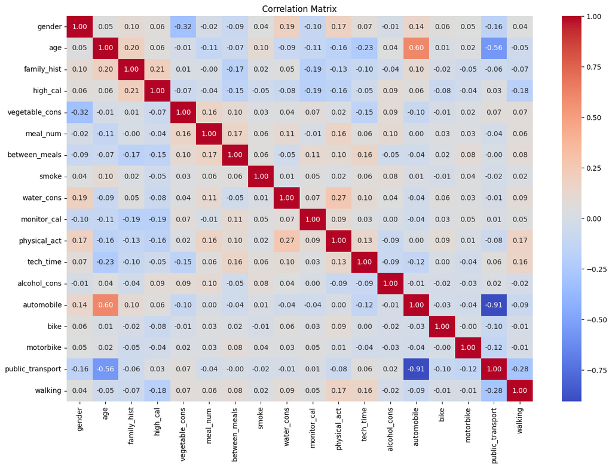

```python
#creates and plots a correlation matrix
corrMatrix = features_df.corr()

plt.figure(figsize = (15,10))
sns.heatmap(corrMatrix, annot=True, cmap='coolwarm', fmt=".2f")
plt.title('Correlation Matrix')
plt.show()
```

Most of the pairs result in a correlation around 0, indicated by the gray squares. Some pairs are shown to be more correlated (either positively or negatively) such as:

- `age` and `automobile`
- `age` and `public_transport`
- `automobile` and `public_transport`

The `public_transport` variable may cause an issue of multicollinearity. We will also look at the variance inflation factor and make decisions about the variables.

### Pair plot of BMI vs. Age

`age` is the only continuous variable in the feature set. We will plot this along with `bmi` on the $y$-axis. This is a check to see what the relationship is like between the variables and if `age` is a good indication of `bmi` level.

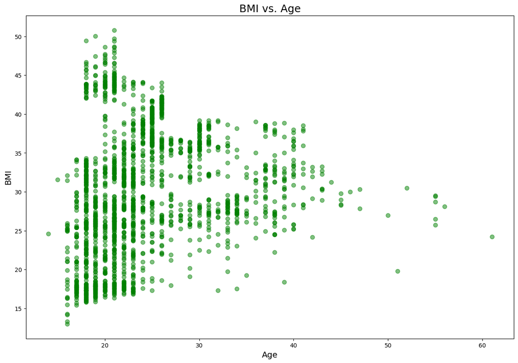

```python
#creates and plots a pair plot
plt.figure(figsize=(15, 10))
plt.scatter(features_df['age'], dataFinal['bmi'], s = 50, alpha = .5, color = 'green')
plt.ylabel('BMI', fontsize = 14)
plt.xlabel('Age', fontsize = 14)
plt.title('BMI vs. Age', fontsize = 18)
```

The plot shows a reverse trumpet shape. The spread of `bmi` levels shows that age will not be a good predictor alone. We will also use the variance inflation factor to investigate this variable further.

### Variance Inflation Factor (VIF)

Next we will form a matrix, $X$, and vector, $y$. These will be used in later sections. We can use the variance inflation factor to narrow down our predictors while reducing the likelihood of collinearity. Our threshold for vif is 5, which is a bit on the conservative side. We will drop the predictors with the highest vif until we are left with all predictors where their corresponding vif is less than 5.

```python
#creates matrix X and vector y
X = features_df
y = dataFinal['bmi']
```

The following function will create a dataframe of the features and vif values so that we can see check if any feature needs to be dropped.

```python
#function to calculate vif of features
def calculate_vif(df):
    vifData = pd.DataFrame()
    vifData['feature'] = df.columns
    vifData['vif'] = [variance_inflation_factor(df.values, i) for i in range(X.shape[1])]
    return vifData
```

```python
calculate_vif(X)
```

|  | feature | vif |
| --- | --- | --- |
| 0 | gender | 1.258677 |
| 1 | age | 1.840592 |
| 2 | family_hist | 1.165643 |
| 3 | high_cal | 1.152623 |
| 4 | vegetable_cons | 1.217755 |
| 5 | meal_num | 1.122559 |
| 6 | between_meals | 1.130944 |
| 7 | smoke | 1.046579 |
| 8 | water_cons | 1.161353 |
| 9 | monitor_cal | 1.098640 |
| 10 | physical_act | 1.238904 |
| 11 | tech_time | 1.170148 |
| 12 | alcohol_cons | 1.068117 |
| 13 | automobile | 17.602204 |
| 14 | bike | 1.228060 |
| 15 | motorbike | 1.372148 |
| 16 | public_transport | 41.172914 |
| 17 | walking | 2.651844 |

```python
#drops a column and calls function again
X = X.drop(columns = 'public_transport')

calculate_vif(X)
```

|  | feature | vif |
| --- | --- | --- |
| 0 | gender | 2.478511 |
| 1 | age | 16.373529 |
| 2 | family_hist | 6.202821 |
| 3 | high_cal | 8.266651 |
| 4 | vegetable_cons | 5.817711 |
| 5 | meal_num | 3.163034 |
| 6 | between_meals | 6.773537 |
| 7 | smoke | 1.053058 |
| 8 | water_cons | 2.771590 |
| 9 | monitor_cal | 1.124470 |
| 10 | physical_act | 2.128778 |
| 11 | tech_time | 1.601339 |
| 12 | alcohol_cons | 3.161708 |
| 13 | automobile | 1.907729 |
| 14 | bike | 1.026425 |
| 15 | motorbike | 1.031035 |
| 16 | walking | 1.124147 |

```python
#drops a column and calls function again
X = X.drop(columns = 'age')

calculate_vif(X)
```

|  | feature | vif |
| --- | --- | --- |
| 0 | gender | 2.443351 |
| 1 | family_hist | 5.503080 |
| 2 | high_cal | 7.320829 |
| 3 | vegetable_cons | 5.379234 |
| 4 | meal_num | 3.147228 |
| 5 | between_meals | 5.940882 |
| 6 | smoke | 1.047086 |
| 7 | water_cons | 2.762356 |
| 8 | monitor_cal | 1.124329 |
| 9 | physical_act | 2.126547 |
| 10 | tech_time | 1.598084 |
| 11 | alcohol_cons | 3.056031 |
| 12 | automobile | 1.346293 |
| 13 | bike | 1.022625 |
| 14 | motorbike | 1.028334 |
| 15 | walking | 1.119881 |

```python
#drops a column and calls function again
X = X.drop(columns = 'high_cal')

calculate_vif(X)
```

|  | feature | vif |
| --- | --- | --- |
| 0 | gender | 2.359691 |
| 1 | family_hist | 4.557732 |
| 2 | vegetable_cons | 5.174775 |
| 3 | meal_num | 3.143213 |
| 4 | between_meals | 5.632708 |
| 5 | smoke | 1.039208 |
| 6 | water_cons | 2.762344 |
| 7 | monitor_cal | 1.118115 |
| 8 | physical_act | 2.126228 |
| 9 | tech_time | 1.582341 |
| 10 | alcohol_cons | 2.866207 |
| 11 | automobile | 1.340896 |
| 12 | bike | 1.017529 |
| 13 | motorbike | 1.028068 |
| 14 | walking | 1.093151 |

```python
#drops a column and calls function again
X = X.drop(columns = 'between_meals')
calculate_vif(X)
```

|  | feature | vif |
| --- | --- | --- |
| 0 | gender | 2.331985 |
| 1 | family_hist | 4.389560 |
| 2 | vegetable_cons | 4.445389 |
| 3 | meal_num | 3.006580 |
| 4 | smoke | 1.039200 |
| 5 | water_cons | 2.758620 |
| 6 | monitor_cal | 1.101704 |
| 7 | physical_act | 2.095790 |
| 8 | tech_time | 1.467248 |
| 9 | alcohol_cons | 2.813104 |
| 10 | automobile | 1.334275 |
| 11 | bike | 1.017493 |
| 12 | motorbike | 1.021611 |
| 13 | walking | 1.093136 |

Our $X$ now has all predictors with vif less than 5. We can see that the following columns remain:

```python
X.head()
```

|  | gender | family_hist | vegetable_cons | meal_num | smoke | water_cons | monitor_cal | physical_act | tech_time | alcohol_cons | automobile | bike | motorbike | walking |
| --- | --- | --- | --- | --- | --- | --- | --- | --- | --- | --- | --- | --- | --- | --- |
| 0 | 0 | 1 | 1 | 1 | 0 | 1 | 0 | 0 | 1 | 0 | 0 | 0 | 0 | 0 |
| 1 | 0 | 1 | 2 | 1 | 1 | 2 | 1 | 3 | 0 | 1 | 0 | 0 | 0 | 0 |
| 2 | 1 | 1 | 1 | 1 | 0 | 1 | 0 | 2 | 1 | 2 | 0 | 0 | 0 | 0 |
| 3 | 1 | 0 | 2 | 1 | 0 | 1 | 0 | 2 | 0 | 2 | 0 | 0 | 0 | 1 |
| 4 | 1 | 0 | 1 | 0 | 0 | 1 | 0 | 0 | 0 | 1 | 0 | 0 | 0 | 0 |

## OLS Regression

Before starting with our OLS regression model, recall that we created our vector $y$ and matrix $X$. We will now split them into training and testing sets.

### Training and Testing Split

```python
#splits X and y into training and test sets
X_train, X_test, y_train, y_test = train_test_split(X, y, test_size = 0.2, random_state = 1)
```

### Ranking Linear Models by Mean Squared Error (MSE)

The following cell loops through every possible combination of predictors. This takes several minutes to run. You can run this if you would like, but I have done this already and have indicated which model is chosen after this has run.

```python
# This takes several minutes to run. You can run this if you would like,
# but I have done this already and have indicated which model is chosen after this has run.

# bestFeatures = None
# bestModel = None
# best_mse = float('inf')

# for k in range(1, len(X_train.columns) + 1):
#   for comb in combinations(X_train.columns, k):
#     loopModel = LinearRegression()
#     loopModel.fit(X_train[list(comb)], y_train)

#     y_pred = loopModel.predict(X_test[list(comb)])

#     mse = mean_squared_error(y_test, y_pred)

#     if mse < best_mse:
#       bestFeatures = list(comb)
#       bestModel = loopModel
#       best_mse = mse

# print(bestFeatures)
# print(best_mse)
```

The following cell saves the chosen best features and the $MSE$ of the respective model. We can see that the lowest $MSE$ is approximately 37.042.

```python
#these were obtained after running the previous cell
#they are saved for convenience
savedbestFeatures = ['gender', 'family_hist', 'vegetable_cons', 'monitor_cal', 'physical_act', 'tech_time', 'alcohol_cons']
savedbest_mse = 37.04187081864214
```

To gain more information on the model, we will use the `statsmodels` library.

```python
#converts previous cells info into a useable format for statmodels
sklearnPred_string = ' + '.join(savedbestFeatures)
sklearnFormula = f'bmi ~ {sklearnPred_string}'

trainData = pd.concat([X_train, y_train], axis=1)

#recreates model and prints summary
sklearnModel = smf.ols(formula=sklearnFormula, data=trainData).fit()

print(sklearnModel.summary())
```

```
                            OLS Regression Results
==============================================================================
Dep. Variable:                    bmi   R-squared:                       0.410
Model:                            OLS   Adj. R-squared:                  0.407
Method:                 Least Squares   F-statistic:                     166.7
Date:                Wed, 29 May 2024   Prob (F-statistic):          2.65e-187
Time:                        06:21:26   Log-Likelihood:                -5466.9
No. Observations:                1688   AIC:                         1.095e+04
Df Residuals:                    1680   BIC:                         1.099e+04
Df Model:                           7
Covariance Type:            nonrobust
==================================================================================
                     coef    std err          t      P>|t|      [0.025      0.975]
----------------------------------------------------------------------------------
Intercept         19.6995      0.605     32.535      0.000      18.512      20.887
gender             0.1163      0.327      0.356      0.722      -0.525       0.758
family_hist        8.8899      0.402     22.127      0.000       8.102       9.678
vegetable_cons     3.1420      0.270     11.647      0.000       2.613       3.671
monitor_cal       -3.5804      0.744     -4.814      0.000      -5.039      -2.122
physical_act      -1.6984      0.188     -9.035      0.000      -2.067      -1.330
tech_time         -2.5596      0.264     -9.710      0.000      -3.077      -2.043
alcohol_cons       1.7676      0.298      5.938      0.000       1.184       2.351
==============================================================================
Omnibus:                       42.542   Durbin-Watson:                   1.988
Prob(Omnibus):                  0.000   Jarque-Bera (JB):               35.084
Skew:                          -0.279   Prob(JB):                     2.41e-08
Kurtosis:                       2.567   Cond. No.                         11.3
==============================================================================

Notes:
[1] Standard Errors assume that the covariance matrix of the errors is correctly specified.
```

In the summary above, we can see that `gender` is not statistically signficant to the model. We will proceed with backward elimination and ensure that we remove all insignificant predictors.

#### Backward Elimation by P-Value on Lowest MSE Model

```python
#drops gender and puts variables into format for statmodels
backelimFeatures = ['family_hist', 'vegetable_cons', 'monitor_cal', 'physical_act', 'tech_time', 'alcohol_cons']
sklearnPred_string2 = ' + '.join(backelimFeatures)
sklearnFormula2 = f'bmi ~ {sklearnPred_string2}'

#creates new model and prints summary
sklearnModel2 = smf.ols(formula=sklearnFormula2, data=trainData).fit()

print(sklearnModel2.summary())
```

```
                            OLS Regression Results
==============================================================================
Dep. Variable:                    bmi   R-squared:                       0.410
Model:                            OLS   Adj. R-squared:                  0.408
Method:                 Least Squares   F-statistic:                     194.5
Date:                Wed, 29 May 2024   Prob (F-statistic):          1.94e-188
Time:                        06:21:26   Log-Likelihood:                -5467.0
No. Observations:                1688   AIC:                         1.095e+04
Df Residuals:                    1681   BIC:                         1.099e+04
Df Model:                           6
Covariance Type:            nonrobust
==================================================================================
                     coef    std err          t      P>|t|      [0.025      0.975]
----------------------------------------------------------------------------------
Intercept         19.7693      0.573     34.520      0.000      18.646      20.893
family_hist        8.9078      0.399     22.353      0.000       8.126       9.689
vegetable_cons     3.1112      0.255     12.180      0.000       2.610       3.612
monitor_cal       -3.5984      0.742     -4.851      0.000      -5.053      -2.143
physical_act      -1.6851      0.184     -9.151      0.000      -2.046      -1.324
tech_time         -2.5582      0.263     -9.709      0.000      -3.075      -2.041
alcohol_cons       1.7715      0.297      5.957      0.000       1.188       2.355
==============================================================================
Omnibus:                       43.263   Durbin-Watson:                   1.988
Prob(Omnibus):                  0.000   Jarque-Bera (JB):               35.323
Skew:                          -0.278   Prob(JB):                     2.14e-08
Kurtosis:                       2.560   Cond. No.                         10.8
==============================================================================

Notes:
[1] Standard Errors assume that the covariance matrix of the errors is correctly specified.
```

```python
#calculates mse of new model
y_pred = sklearnModel2.predict(X_test)

mse = mean_squared_error(y_test, y_pred)

print(f'MSE of the model is {mse}')
```

```
MSE of the model is 37.06127418508299
```

All predictors that remain are statistically significant. Note that the Adjusted $R^{2}$ is 0.408 and that the $MSE$ is 37.061. $R^{2}$ is rather low while the $MSE$ is rather high since we are looking at BMI. This should be a cause for concern and we will investigate this further.

### Forward Selection by P-Value

Let's compare the previous linear model to another model created by forward selection using p-values.

```python
#performs forward selection using p-values
predictorList = X

alpha = 0.05

selectedPredictors = []

while len(selectedPredictors) < len(predictorList):
    remaining_predictors = [p for p in predictorList if p not in selectedPredictors]

    pVal_list = []

    for predictor in remaining_predictors:
        loopFormula = f'bmi ~ {" + ".join(selectedPredictors + [predictor])}'

        model = smf.ols(formula = loopFormula, data = trainData).fit()

        pVal = model.pvalues[predictor]

        pVal_list.append((predictor, pVal))

    minPred, min_pVal = min(pVal_list, key=lambda x: x[1])

    if min_pVal < alpha:
        selectedPredictors.append(minPred)
        print(f'Added predictor: {minPred} with p-value: {min_pVal}')
    else:
        break

print("Selected Predictors:", selectedPredictors)
```

```
Added predictor: family_hist with p-value: 1.3581881843213637e-100
Added predictor: vegetable_cons with p-value: 1.5285296415596516e-36
Added predictor: tech_time with p-value: 2.195105903798932e-28
Added predictor: physical_act with p-value: 2.2287588384559776e-22
Added predictor: alcohol_cons with p-value: 2.7193452984051365e-09
Added predictor: monitor_cal with p-value: 1.342658111394102e-06
Added predictor: automobile with p-value: 1.3095695184131262e-06
Added predictor: walking with p-value: 0.0014311361060429422
Selected Predictors: ['family_hist', 'vegetable_cons', 'tech_time', 'physical_act', 'alcohol_cons', 'monitor_cal', 'automobile', 'walking']
```

```python
#reformats the previous cell's result to statmodels format
finalFormula = f'bmi ~ {" + ".join(selectedPredictors)}'

#recreates model and prints summary
finalModel = smf.ols(formula=finalFormula, data=trainData).fit()

print(finalModel.summary())
```

```
                            OLS Regression Results
==============================================================================
Dep. Variable:                    bmi   R-squared:                       0.422
Model:                            OLS   Adj. R-squared:                  0.419
Method:                 Least Squares   F-statistic:                     152.9
Date:                Wed, 29 May 2024   Prob (F-statistic):          2.11e-193
Time:                        06:21:28   Log-Likelihood:                -5450.1
No. Observations:                1688   AIC:                         1.092e+04
Df Residuals:                    1679   BIC:                         1.097e+04
Df Model:                           8
Covariance Type:            nonrobust
==================================================================================
                     coef    std err          t      P>|t|      [0.025      0.975]
----------------------------------------------------------------------------------
Intercept         20.1798      0.577     34.965      0.000      19.048      21.312
family_hist        9.0215      0.396     22.780      0.000       8.245       9.798
vegetable_cons     3.0345      0.256     11.868      0.000       2.533       3.536
tech_time         -2.6356      0.266     -9.903      0.000      -3.158      -2.114
physical_act      -1.5746      0.185     -8.533      0.000      -1.937      -1.213
alcohol_cons       1.7904      0.295      6.076      0.000       1.212       2.368
monitor_cal       -3.5926      0.736     -4.884      0.000      -5.035      -2.150
automobile        -1.8894      0.375     -5.038      0.000      -2.625      -1.154
walking           -3.0180      0.945     -3.194      0.001      -4.872      -1.164
==============================================================================
Omnibus:                       45.862   Durbin-Watson:                   1.992
Prob(Omnibus):                  0.000   Jarque-Bera (JB):               37.469
Skew:                          -0.288   Prob(JB):                     7.31e-09
Kurtosis:                       2.553   Cond. No.                         13.8
==============================================================================

Notes:
[1] Standard Errors assume that the covariance matrix of the errors is correctly specified.
```

```python
#calculates mse of latest model
y_pred = finalModel.predict(X_test)

mse = mean_squared_error(y_test, y_pred)

print(f'MSE of the model is {mse}')
```

```
MSE of the model is 37.17484592403045
```

This new model slightly increases the adjusted $R^{2}$ to 0.419. The $MSE$ also increases slightly to 37.175. This model has more predictors with a larger $MSE$ and a minimal increase to $R^{2}$. Our previous model, `sklearnModel2` is a better option.

### Diagnostic Plots

We proceed by looking at the diagnostic plots for `sklearnModel2`.

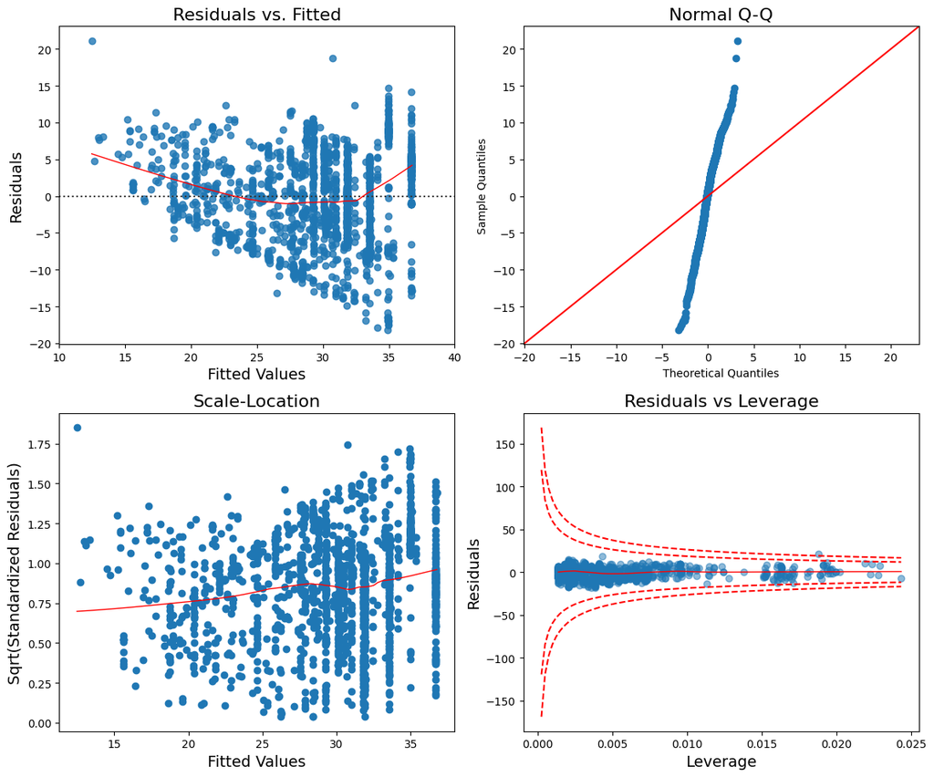

```python
#creates 4 diagnostic plots similar to ones found in R
fittedVals = sklearnModel2.fittedvalues
residuals = sklearnModel2.resid

fig, axs = plt.subplots(2, 2, figsize=(12, 10))

#residual vs fitted
sns.residplot(x = fittedVals, y = residuals, lowess = True, line_kws = {'color': 'red', 'lw': 1}, ax = axs[0, 0])
axs[0, 0].set_xlabel('Fitted Values', fontsize=14)
axs[0, 0].set_ylabel('Residuals', fontsize=14)
axs[0, 0].set_title('Residuals vs. Fitted', fontsize=16)
axs[0, 0].set_xlim(10, 40)

#normal q-q plot
qqplot(residuals, line = '45', ax = axs[0, 1])
axs[0, 1].set_title('Normal Q-Q', fontsize=16)

#scale location plot
standardized_residuals = residuals / np.std(residuals)
sqrt_standardized_residuals = np.sqrt(np.abs(standardized_residuals))
axs[1, 0].scatter(fittedVals, sqrt_standardized_residuals)
sns.regplot(x = fittedVals, y = sqrt_standardized_residuals, scatter = False, lowess = True, line_kws = {'color': 'red', 'lw': 1}, ax = axs[1, 0])
axs[1, 0].set_xlabel('Fitted Values', fontsize=14)
axs[1, 0].set_ylabel('Sqrt(Standardized Residuals)', fontsize=14)
axs[1, 0].set_title('Scale-Location', fontsize=16)

#information and plot for residual vs leverage
influence = sklearnModel2.get_influence()
leverage = influence.hat_matrix_diag
cooks = influence.cooks_distance[0]
axs[1, 1].scatter(leverage, residuals, alpha=0.5)
sns.regplot(x = leverage, y = residuals, scatter = False, lowess = True, line_kws = {'color': 'red', 'lw': 1}, ax = axs[1, 1])
axs[1, 1].set_xlabel('Leverage', fontsize=14)
axs[1, 1].set_ylabel('Residuals', fontsize=14)
axs[1, 1].set_title('Residuals vs Leverage', fontsize=16)
p = len(sklearnModel2.params)
x = np.linspace(0, max(leverage), 100)
for i in [0.5, 1]:
    axs[1, 1].plot(x, np.sqrt(i * (p * (1 - x) / x)), linestyle = '--', color = 'red')
    axs[1, 1].plot(x, -np.sqrt(i * (p * (1 - x) / x)), linestyle = '--', color = 'red')

#shows all plots
plt.tight_layout()
plt.show()
```

There are two striking issues in our diagnostic plots.

1. For the Residuals vs. Fitted plot, there is a curved shape. Points on the left of the plot are mostly positive and/or near 0. There is also a slight trumpet shape. These indicate that the homoscedasticity assumption is violated by the model.
2. In the Normal Q-Q plot, the tails are very heavy to the point that the plot is near vertical. This indicates that the normality assumption has been violated.

The Scale-Location plot is relatively spread out. There is a slight shape to it, which supports what we saw in the Residuals vs. Fitted plot. The Residuals vs. Leverage plot has one point on the outer border, but there are no extremely influential points.

### OLS Regression Conclusion

In the models that we looked at we saw mediocre adjusted $R^2$ values and high $MSE$ values. Even after our feature engineering process (MSE ranking, backward elimination, and forward selction), the models all performed poorly. The diagnostic plots gave us some reasoning as to why they were poor. There are violations to homoscedasticity and normality assumptions that are required for OLS Regression.

We need to find more appropriate models. More specifically, we need to use models that are robust in regards to collinearity, heteroscedasticity, and lack of normality. We will switch our focus to Ensembles.

## Ensemble Methods

### Bagging with Random Forests and Boosting with XGBoost

In order to find a more accurate model, we will focus on Random Forests and XGBoost. Rather than using regression to predict `bmi`, we will go the classification route using `obesity_class`.

### Random Forest Classification

First we are going to revisit `dataFinal` from our data cleaning section. We will create a new dataset where we drop `bmi` since we are performing classification on `obesity_class`.

```python
dataFinal.info()
```

```
<class 'pandas.core.frame.DataFrame'>
RangeIndex: 2111 entries, 0 to 2110
Data columns (total 20 columns):
 #   Column            Non-Null Count  Dtype
---  ------            --------------  -----
 0   gender            2111 non-null   int64
 1   age               2111 non-null   float64
 2   family_hist       2111 non-null   int64
 3   high_cal          2111 non-null   int64
 4   vegetable_cons    2111 non-null   int64
 5   meal_num          2111 non-null   int64
 6   between_meals     2111 non-null   int64
 7   smoke             2111 non-null   int64
 8   water_cons        2111 non-null   int64
 9   monitor_cal       2111 non-null   int64
 10  physical_act      2111 non-null   int64
 11  tech_time         2111 non-null   int64
 12  alcohol_cons      2111 non-null   int64
 13  automobile        2111 non-null   int64
 14  bike              2111 non-null   int64
 15  motorbike         2111 non-null   int64
 16  public_transport  2111 non-null   int64
 17  walking           2111 non-null   int64
 18  bmi               2111 non-null   float64
 19  obesity_class     2111 non-null   object
dtypes: float64(2), int64(17), object(1)
memory usage: 330.0+ KB
```

```python
#removes bmi since we are using obesity class for classification
rf_df = dataFinal.drop(columns=['bmi'])
rf_df.info()
```

```
<class 'pandas.core.frame.DataFrame'>
RangeIndex: 2111 entries, 0 to 2110
Data columns (total 19 columns):
 #   Column            Non-Null Count  Dtype
---  ------            --------------  -----
 0   gender            2111 non-null   int64
 1   age               2111 non-null   float64
 2   family_hist       2111 non-null   int64
 3   high_cal          2111 non-null   int64
 4   vegetable_cons    2111 non-null   int64
 5   meal_num          2111 non-null   int64
 6   between_meals     2111 non-null   int64
 7   smoke             2111 non-null   int64
 8   water_cons        2111 non-null   int64
 9   monitor_cal       2111 non-null   int64
 10  physical_act      2111 non-null   int64
 11  tech_time         2111 non-null   int64
 12  alcohol_cons      2111 non-null   int64
 13  automobile        2111 non-null   int64
 14  bike              2111 non-null   int64
 15  motorbike         2111 non-null   int64
 16  public_transport  2111 non-null   int64
 17  walking           2111 non-null   int64
 18  obesity_class     2111 non-null   object
dtypes: float64(1), int64(17), object(1)
memory usage: 313.5+ KB
```

#### New $X$ and $y$ with Training and Testing Split

We will create a new $X$ and $y$ here. Since Random Forests are more robust, we can include more of our original features unlike our steps with OLS Regression. There is a risk of overfitting, but we can tune the hyperparameters to adjust for this. We can also split the data into training and testing sets.

```python
#creates new X and y then splits into training and test sets
X = rf_df.drop(columns = ['obesity_class'])
y = rf_df['obesity_class']

X_train, X_test, y_train, y_test = train_test_split(X, y, test_size = 0.2, random_state = 1)
```

#### Hyperparameter Tuning

We will adjust two hyperparameters. The first is setting `max_features = 'sqrt'`. This reduces the number of features considered when splitting and will help address overfitting. The second hyperparameter is the number of trees, i.e. `n_estimators`.

The following cell creates a list of values for `n_estimators` and loops through each value to find the corresponding accuracy.

```python
#creates loop for random forest models with different estimator amounts
n_estimatorsList = [1, 10, 50, 100, 200, 300, 500, 750, 1000]

accuracyValues = []

for n in n_estimatorsList:
    rfClassifier = RandomForestClassifier(n_estimators = n, random_state = 1, max_features = 'sqrt')
    rfClassifier.fit(X_train, y_train)

    y_pred = rfClassifier.predict(X_test)
    accuracy = accuracy_score(y_test, y_pred)

    accuracyValues.append(accuracy)

    print(f'Accuracy with {n} estimators: {accuracy}')
```

```
Accuracy with 1 estimators: 0.6926713947990544
Accuracy with 10 estimators: 0.7635933806146572
Accuracy with 50 estimators: 0.7683215130023641
Accuracy with 100 estimators: 0.7612293144208038
Accuracy with 200 estimators: 0.7683215130023641
Accuracy with 300 estimators: 0.7730496453900709
Accuracy with 500 estimators: 0.7683215130023641
Accuracy with 750 estimators: 0.7706855791962175
Accuracy with 1000 estimators: 0.7730496453900709
```

#### Plots and Results

##### Accuracy Plot

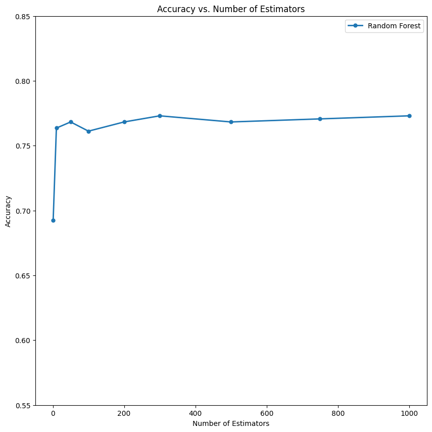

```python
#plots accuracy vs number of estimators using previous cell's info
plt.figure(figsize = (10,10))
plt.plot(n_estimatorsList, accuracyValues, marker = '.', linewidth = 2, markersize = 10, label = 'Random Forest')
plt.xlabel('Number of Estimators')
plt.ylabel('Accuracy')
plt.title('Accuracy vs. Number of Estimators')
plt.ylim(0.55, 0.85)
plt.legend()
plt.show()
```

From the output values and the plot we can see that the highest accuracy was achieved with 300 estimators. It is also reasonable to use 50 estimators since the accuracy is very close, but with less trees. Comparing 300 trees to 50 trees, there is less than 0.005 increase to accuracy at the expense of adding 250 more trees.

##### Confusion Matrix

We will look at the confusion matrix for the random forest model with 50 trees.

```python
rfClassifier = RandomForestClassifier(n_estimators = 50, random_state = 1, max_features = 'sqrt')
rfClassifier.fit(X_train, y_train)

y_pred = rfClassifier.predict(X_test)
```

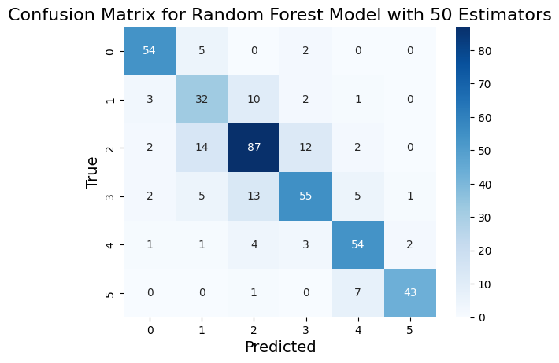

```python
labeling = ['Underweight', 'Normal', 'Overweight', 'Obesity_I', 'Obesity_II', 'Obesity_III']
rf_cm = confusion_matrix(y_test, y_pred, labels = labeling)
sns.heatmap(rf_cm, annot = True, cmap = 'Blues')
plt.xlabel('Predicted', fontsize = 14)
plt.ylabel('True', fontsize = 14)
plt.title('Confusion Matrix for Random Forest Model with 50 Estimators', fontsize = 16)
plt.show()
```

We can see that the model performs better with more extreme values. The middle categories, in particular `Normal` (1), `Overweight` (2), and `Obesity_I` (3), tended to be misclassified with neighboring classes more often.

##### Classification Report

Below is the classification report for the model with 50 trees.

```python
rf_report = classification_report(y_test, y_pred, labels = labeling)
print(rf_report)
```

```
              precision    recall  f1-score   support

 Underweight       0.87      0.89      0.88        61
      Normal       0.56      0.67      0.61        48
  Overweight       0.76      0.74      0.75       117
   Obesity_I       0.74      0.68      0.71        81
  Obesity_II       0.78      0.83      0.81        65
 Obesity_III       0.93      0.84      0.89        51

    accuracy                           0.77       423
   macro avg       0.77      0.77      0.77       423
weighted avg       0.77      0.77      0.77       423
```

We can get a sense of how well the model performs with respect to each class by looking at the F1-score. This is a good way to account for class imbalances present in the data.

`Underweight`, `Obesity_II`, and `Obesity_III` have rather high F1-scores.

`Overweight` and `Obesity_I` have somewhat high F1-scores.

`Normal` results in an average F1-score. It is possible that this is due to an imbalance in the category counts (support), but we can see that the other categories with similar support numbers have higher F1-scores.

### XGBoost Classification

Next we will use XGBoost for classification. We first need to make some changes to our target variable. XGBoost requires that the target variable be in integer format for categories. We will map the categories in an ordinal fashion.

```python
#remaps the target variable column to align with xgboost format
targetMap = {'Underweight': 0, 'Normal': 1, 'Overweight': 2, 'Obesity_I': 3, 'Obesity_II': 4, 'Obesity_III': 5}
data_xgb = dataFinal.applymap(lambda x: targetMap.get(x, x))
```

#### New $y$ with Training and Testing Split

We can use the same $X$ as before. We have a new $y$ since we had to adjust the categories in the target variable column. Note, that since X is identical and there are still the same number of rows, the `random_state` parameter ensures that the training and testing sets are the same for both the Random Forest sets and the XGBoost sets.

```python
#creates new y the splits data for training and testing sets
y = data_xgb['obesity_class']

X_train, X_test, y_train, y_test = train_test_split(X, y, test_size = 0.2, random_state = 1)
```

#### Hyperparameter Tuning

We will adjust `subsample` and `colsample_bytree`. By making the subsample ratio smaller and by reducing the number of features for each tree, we can try to prevent overfitting. Just like we did in the Random Forest section, we will also tune `n_estimators` by using a loop through different values.

```python
#creates loop for xgboost models with different estimator amounts
accuracyValuesXGB = []

for n in n_estimatorsList:
    xgbClassifier = xgb.XGBClassifier(n_estimators = n, random_state = 1, subsample = 0.5, colsample_bytree = 0.8)
    xgbClassifier.fit(X_train, y_train)

    y_pred = xgbClassifier.predict(X_test)
    accuracy = accuracy_score(y_test, y_pred)

    accuracyValuesXGB.append(accuracy)

    print(f'Accuracy with {n} estimators: {accuracy}')
```

```
Accuracy with 1 estimators: 0.5957446808510638
Accuracy with 10 estimators: 0.7257683215130024
Accuracy with 50 estimators: 0.7777777777777778
Accuracy with 100 estimators: 0.7683215130023641
Accuracy with 200 estimators: 0.75177304964539
Accuracy with 300 estimators: 0.7565011820330969
Accuracy with 500 estimators: 0.7588652482269503
Accuracy with 750 estimators: 0.7470449172576832
Accuracy with 1000 estimators: 0.7423167848699763
```

#### Plots and Results

##### Accuracy Plot

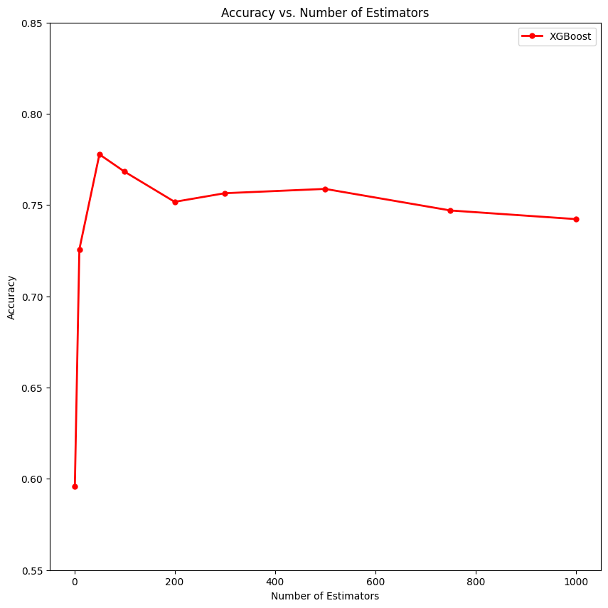

```python
#plots accuracy vs number of estimators using previous cell's info
plt.figure(figsize = (10,10))
plt.plot(n_estimatorsList, accuracyValuesXGB, marker = '.', linewidth = 2, markersize = 10, color = 'red', label = 'XGBoost')
plt.xlabel('Number of Estimators')
plt.ylabel('Accuracy')
plt.title('Accuracy vs. Number of Estimators')
plt.ylim(0.55, 0.85)
plt.legend()
plt.show()
```

We can see by the output values and plot that 50 estimators is the most accurate model.

##### Confusion Matrix

We will look at the confusion matrix for the XGBoost model with 50 trees.

```python
xgbClassifier = xgb.XGBClassifier(n_estimators = 50, random_state = 1, subsample = 0.5, colsample_bytree = 0.8)
xgbClassifier.fit(X_train, y_train)

y_pred = xgbClassifier.predict(X_test)
```

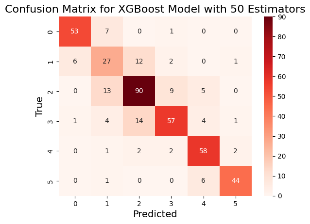

```python
xgb_cm = confusion_matrix(y_test, y_pred)
sns.heatmap(xgb_cm, annot = True, cmap = 'Reds')
plt.xlabel('Predicted', fontsize= 14)
plt.ylabel('True', fontsize= 14)
plt.title('Confusion Matrix for XGBoost Model with 50 Estimators', fontsize= 16)
plt.show()
```

##### Classification Report

```python
xgb_report = classification_report(y_test, y_pred)
print(xgb_report)
```

```
              precision    recall  f1-score   support

           0       0.88      0.87      0.88        61
           1       0.51      0.56      0.53        48
           2       0.76      0.77      0.77       117
           3       0.80      0.70      0.75        81
           4       0.79      0.89      0.84        65
           5       0.92      0.86      0.89        51

    accuracy                           0.78       423
   macro avg       0.78      0.78      0.78       423
weighted avg       0.78      0.78      0.78       423
```

We can get a sense of how well the model performs with respect to each class by looking at the F1-score. This is a good way to account for class imbalances present in the data.

`Underweight` (0), `Obesity_II` (4), and `Obesity_III` (5) have rather high F1-scores.

`Overweight` (2) and `Obesity_I` (3) have somewhat high F1-scores.

`Normal` (1) results in an average F1-score. Again, it is possible that this is due to an imbalance in the category counts (support), but we can see that the other categories with similar support numbers have higher F1-scores.

### Random Forest vs. XGBoost

#### Accuracy Comparison

Below is an accuracy vs. number of estimators plot comparing Random Forest and XGBoost models.

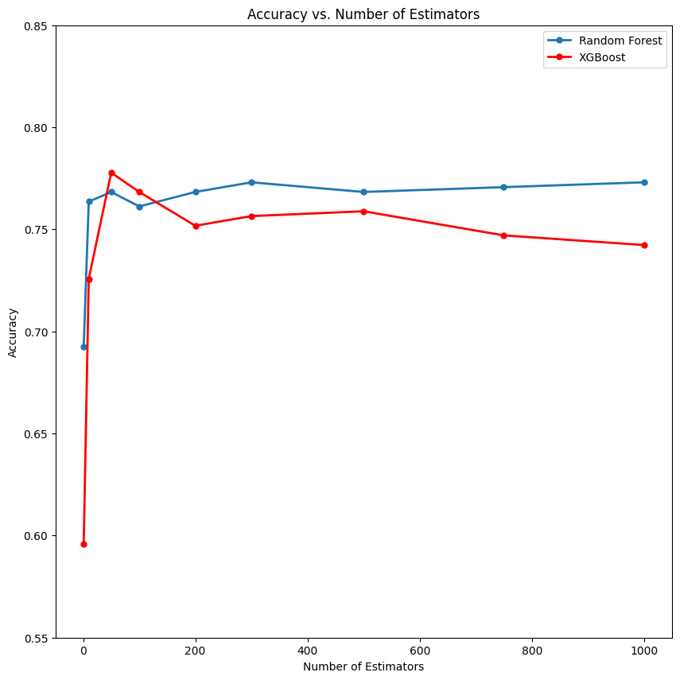

```python
#plots accuracy vs number of estimators
#compares random forest models to xgboost models
plt.figure(figsize = (10,10))
plt.plot(n_estimatorsList, accuracyValues, marker = '.', linewidth = 2, markersize = 10, label = 'Random Forest')
plt.plot(n_estimatorsList, accuracyValuesXGB, marker = '.', linewidth = 2, markersize = 10, color = 'red', label = 'XGBoost')
plt.xlabel('Number of Estimators')
plt.ylabel('Accuracy')
plt.title('Accuracy vs. Number of Estimators')
plt.ylim(0.55, 0.85)
plt.legend()
plt.show()
```

It is clear that the most accurate model is the XGBoost model with 50 estimators.

#### Report Comparison

```python
print('Random Forest Report', rf_report, sep = '\n \n')
print('--------------------','XGBoost Report',xgb_report, sep = '\n \n')
```

```
Random Forest Report

              precision    recall  f1-score   support

 Underweight       0.87      0.89      0.88        61
      Normal       0.56      0.67      0.61        48
  Overweight       0.76      0.74      0.75       117
   Obesity_I       0.74      0.68      0.71        81
  Obesity_II       0.78      0.83      0.81        65
 Obesity_III       0.93      0.84      0.89        51

    accuracy                           0.77       423
   macro avg       0.77      0.77      0.77       423
weighted avg       0.77      0.77      0.77       423

--------------------

XGBoost Report

              precision    recall  f1-score   support

           0       0.88      0.87      0.88        61
           1       0.51      0.56      0.53        48
           2       0.76      0.77      0.77       117
           3       0.80      0.70      0.75        81
           4       0.79      0.89      0.84        65
           5       0.92      0.86      0.89        51

    accuracy                           0.78       423
   macro avg       0.78      0.78      0.78       423
weighted avg       0.78      0.78      0.78       423
```

## Conclusion

### Best Model

Through our work we found that the XGBoost Model with 50 estimators is the best model in terms of accuracy and F1-score metrics. There was a thin margin in better performance when compared to the Random Forest model with 50 trees. One could also make the argument that the Random Forest model is a better option due to similar F1-scores and a higher `Normal` F1-score, though at a value of 0.61 that F1-score is still not amazing.

### Difficulties and Takeaways

I think with every model there is a little bit of difficulty when dealing with parameters and hyperparameters. The trade-off of better performance vs. overfitting is a tricky balancing act.

When choosing this dataset I knew that it would be difficult making predictions and classifications based off of survey data. If I was able to investigate this problem further and collect more data myself, I would change how the data is collected and reported. There were too many options for each feature. Also, many questions were ambiguous and would only worsen response bias.

The OLS Regression models failed in this project. To improve, we would need to focus in on certain relevant features. Smoothing the terms or changing the regression type would involve more research, but it could work out to better performing models.

I learned more about ensemble methods during this project. I learned about applying an XGBoost model, which wasn't covered in the course. The random forest and XGBoost models helped reinforce what we learned throughout our assignments. These models could also be improved. There are numerous hyperparameters that could be tuned. Taking time to test many different options could lead to better results.

Ultimately, we achieved a model with an accuracy of approximately 78%. Considering that this was based on survey responses across many different weight/obesity categories, I am happy with it's performance.